# Abgabe Blatt 10

Leonardo Giannotti - Immatrikulationsnummer: 12635009

Tala Mansour - Immatrikulationsnummer: 12541634

Packages, die in diesem Blatt benutzt wurden:

```r
library(qboxplot)
```

Dieses Package wurde benutzt, da qboxplot einen “Quantil-genauen” Algorithmus für die Erstellung eines Boxplots verwendet.

### Aufgabe 1)

```r
urliste <- c(3300, 9000, 2700, 6500, 3600, 1500, 1000, 1500, 1000, 2100, 1800, 2800,
             1800, 4600, 3200, 2700)
```

#### 1a)

#### *Geben Sie das arithmetische Mittel sowie den Median und die beiden Quartile an.*

**Das arithmetische Mittel**:
Formel des arithmetischen Mittels:
$$\overline{x} = \frac{1}{n} \sum_{i = 1}^{n}
x_i$$
Das arithetische Mittel erhalten wir durch den Befehl **mean**.

```r
arith_mit <- mean(urliste)
arith_mit
```

```
## [1] 3068.75
```

**Der Median:**
Der Median ist der mittlere Wert der geordneten Daten:
Falls $k = \frac{n+1}{2}$ eine ganze Zahl ist:
$$x_{med} = x_{k}$$
Falls $k = \frac{n}{2}$ eine ganze Zahl ist:
$$x_{med} = \frac{1}{2}(x_{k} +
x_{k+1})$$
Den Median erhalten wir durch den Befehl **median**.

```r
median <- median(urliste)
median
```

```
## [1] 2700
```

Allerdings müssten wir, wenn wir den Median händisch berechnen wollen, alle Datenpunkte der Größe nach sortieren und anschließend den mittleren Wert berechnen oder ausfindig machen. Hierfür kann man den Befehl **sort** verwenden.

```r
sort_urliste <- sort(urliste)
sort_urliste
```

```
##  [1] 1000 1000 1500 1500 1800 1800 2100 2700 2700 2800 3200 3300 3600 4600 6500
## [16] 9000
```

Nun haben wir die Daten sortiert und können über den **quantile**-Befehl den Median berechnen:

```r
quantile(sort_urliste, c(0.5), type = 2)
```

```
##  50%
## 2700
```

Oder händisch:

```r
(sort_urliste[8] + sort_urliste[9]) / 2
```

```
## [1] 2700
```

**Quartile:**  
Die Quartile erhalten wir durch den Befehl **quantile**. Allerdings müssen wir hier spzeifizieren, welche Quantile bzw. Quartile wir erhalten wollen.

```r
quantile(urliste, c(0.25, 0.75), type = 2)
```

```
##  25%  75%
## 1650 3450
```

#### 1b)

#### *Zeichnen Sie den modifizierten Boxplot.*

Hierfür benutzten wir den Befehl **qboxplot** aus dem package *qboxplot*.

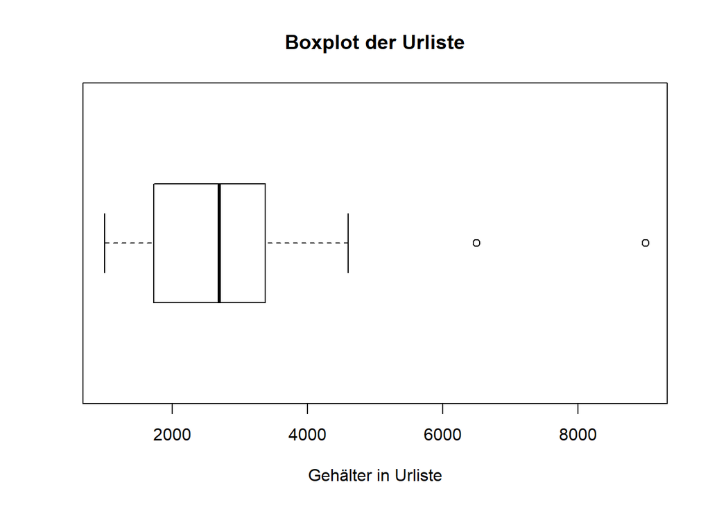

```r
qboxplot(as.data.frame(urliste), xlab = "Gehälter in Urliste", main = "Boxplot der Urliste", type = 2, horizontal = TRUE)
```

#### 1c)

#### *Zeichnen Sie die empirische Verteilungsfunktion.*

Die empirische Verteilungsfunktion erhalten wir in R über den Befehl **ecdf**. Anschließend können wir die Verteilung mit dem Befehl **plot** auch plotten:

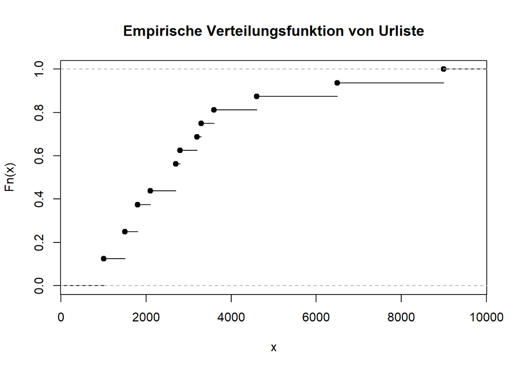

```r
ecdf_urliste <- ecdf(urliste)
plot(ecdf_urliste, main = "Empirische Verteilungsfunktion von Urliste")
```

#### 1d)

#### *Beschreiben Sie kurz die Charakteristika dieser Verteilung mit den in der Vorlesung eingef̈uhrten Begriffen.*

Der empirischen Verteilungsfunktion kann man entnehmen, dass die Verteilung **linkssteil** ist, da sie bei niedrigen x-Werten relativ schnell ansteigt.

### Aufgabe 2)

```r
urliste2 <- c(204,221,195,191,205,220,194,225,185,188,229,
              231,222,239,225,194,211,222,199)
```

#### 2a)

#### *Berechnen Sie die Fünf-Punkte-Zusammenfassung und die Zäune des Boxplots und zeichnen Sie den modifizierten Boxplot.*

Die ‘Fünf-Punkte-Zusammenfassung’ besteht aus:

- Minimum -> in R: min()
- 1.Quartil -> in R: quantile(x, 0.25)
- Median -> in R: median()
- 3.Quartil -> in R: quantile(x, 0.75)
- Maximum -> in R. max()

```r
#Minimum:
min_u2 <- min(urliste2)
cat("Minimum: \n")
print(min_u2)

#1. Quartil:
q1_u2 <- quantile(urliste2, 0.25, type = 2)
cat("\n 1. Quartil: \n")
print(q1_u2)

#Median:
med_u2 <- median(urliste2)
cat("\n Median: \n")
print(med_u2)

#3. Quartil:
q3_u2 <- quantile(urliste2, 0.75, type = 2)
cat("\n 3. Quartil: \n")
print(q3_u2)

#Maximum:
max_u2 <- max(urliste2, type = 2)
cat("\n Maximum: \n")
print(max_u2)
```

```
## Minimum:
## [1] 185
##
##  1. Quartil:
## 25%
## 194
##
##  Median:
## [1] 211
##
##  3. Quartil:
## 75%
## 225
##
##  Maximum:
## [1] 239
```

Nun können wir die Zäune $z_{u}$ und $z_{o}$ berechnen. Hierfür benötigen wir den Interquartilsabstand, denn:
$$z_{u} = x_{0.25} - 1.5*IQR$$
$$z_{o} = x_{0.75} + 1.5*IQR$$
Um in R den Interquartilsabstand zu berechnen, benutzt man den Befehl **IQR**.
Anschließend können wir über simple Mathe-Syntax die Berechnungen durchführen.

```r
iqr <- 225  - 194

z_u <- 194 - (1.5 * iqr)
cat("Zaun unten: \n")
print(z_u)

z_o <- 225 + (1.5 * iqr)
cat("\n Zaun oben: \n")
print(z_o)
```

```
## Zaun unten:
## [1] 147.5
##
##  Zaun oben:
## [1] 271.5
```

Da $min(urliste2)$ und $max(urliste2)$ in dem Intervall der beiden Zäune liegen $[147.5, 271.5]$, befinden sich die Zäune bei den Werten $min(urliste2)$ und $max(urliste2)$.

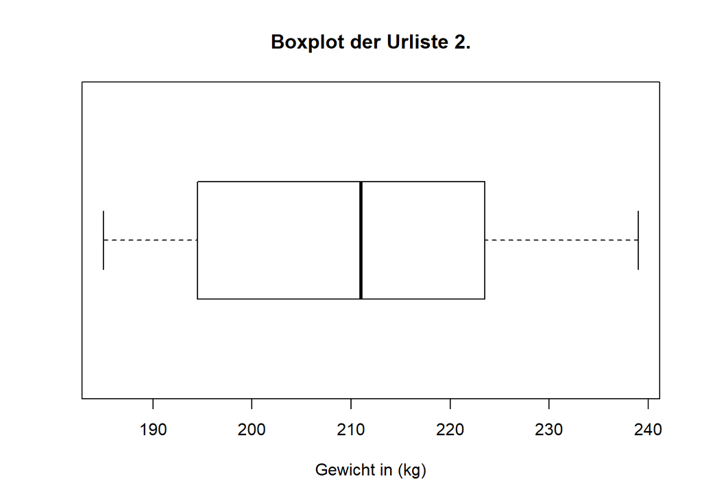

```r
qboxplot(as.data.frame(urliste2), main = "Boxplot der Urliste 2.",
         xlab = "Gewicht in (kg)", horizontal = TRUE)
```

#### 2b)

Um diese Frage zu beantworten, ist es sinnvoll die Daten zu visualisieren - beispielsweise mit einem Kerneldensity-Estimator (Befehl: **density**):

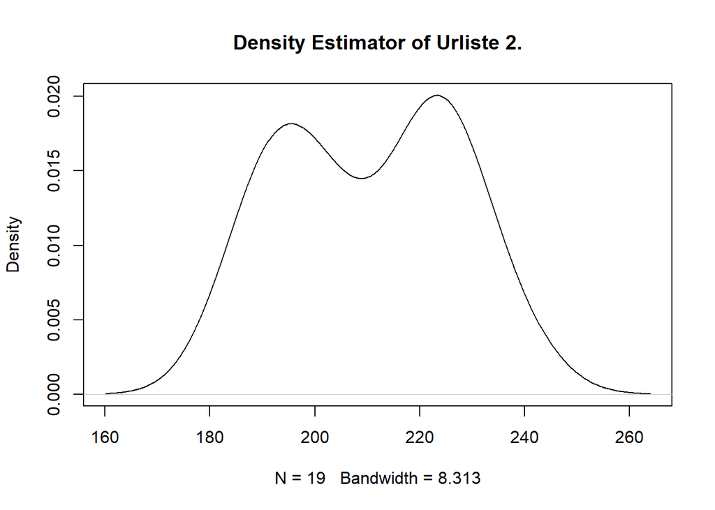

```r
plot(density(urliste2), main = "Density Estimator of Urliste 2.")
```

Dem Plot kann man entnehmen, dass die Daten multimodal verteilt sind. Diese Information konnte man dem Boxplot so nicht entnehmen.

#### 2c)

Hierfür werden wir die Urliste 2. sortieren. Dies mal über den **order** Befehl, da wir vorhaben mit Indizes zu arbeiten.

```r
urliste2_ord <- order(urliste2)
urliste2 <- urliste2[urliste2_ord]

urliste2
```

```
##  [1] 185 188 191 194 194 195 199 204 205 211 220 221 222 222 225 225 229 231 239
```

Nun werden wir die leichtesten 5 Schweine um 2 kg schwerer machen.  
Hierfür programmieren wir eine kleine **for-Schleife**, mit der wir auf eine besonders effiziente Art und Weise die ersten 5 Indizes manipulieren können.

```r
# Wir lassen die Schleife bis 5 laufen und greifen darüber auf die ersten 5 Indizes zu
# und überschreiben diese dann mit dem originalen Wert bloß 2kg schwerer.
for(x in seq(1,5)){
  urliste2[x] <- urliste2[x] + 2
}

urliste2
```

```
##  [1] 187 190 193 196 196 195 199 204 205 211 220 221 222 222 225 225 229 231 239
```

Nun werden wir uns die Quartile erneut anschauen:

```r
cat("1. Quartil: \n")
print(quantile(urliste2, 0.25), type = 2)

cat("\n 3. Quartil: \n")
print(quantile(urliste2, 0.75), type = 2)
```

```
## 1. Quartil:
## 25%
## 196
##
##  3. Quartil:
##   75%
## 223.5
```